# HW5

Rutkovskaya Ekaterina

2024-06-02

## Data uploading

```r
library(ade4)
library(readxl)
library(vegan)
library(ggplot2)
library(plotly)
library(impute)
library(factoextra)
library(psych)
library(ggforce)
library(rstatix)
data(doubs)
fish<- doubs$fish
env <- doubs$env
coord<-doubs$xy
```

## EDA

After some data exploring I noticed that not all sites have fish, so I decided to remove this sites

```r
keep <- apply(fish, 1, sum) > 0
fish <- fish[keep, ]
env <- env[keep, ]
coord <- coord[keep, ]
```

## CCA

Now let’s perform CCA for all environmental factors

```r
cca_env <- cca(fish ~ ., env)
vif.cca(cca_env)
```

```
##        dfs        alt        slo        flo         pH        har        pho
## 182.605627  39.769078   5.044321  79.758369   2.106644   4.626978   9.441795
##        nit        amm        oxy        bdo
##  11.508923  11.802503  15.803977   9.899194
```

Variance inflation factor for distance (dfs) is too high, so let’s remove this factor

```r
no_dfs<-env[,2:11]
cca_env <- cca(fish ~ ., no_dfs)
vif.cca(cca_env)
```

```
##       alt       slo       flo        pH       har       pho       nit       amm
##  9.528225  3.739424  8.079059  1.446417  3.468034  9.060475  8.879419 10.815311
##       oxy       bdo
##  5.826989  9.883829
```

Now the factors are okay and I can continue analysis

```r
summary(cca_env)
```

```
##
## Call:
## cca(formula = fish ~ alt + slo + flo + pH + har + pho + nit +      amm + oxy + bdo, data = no_dfs)
##
## Partitioning of scaled Chi-square:
##               Inertia Proportion
## Total          1.1669     1.0000
## Constrained    0.8140     0.6976
## Unconstrained  0.3529     0.3024
##
## Eigenvalues, and their contribution to the scaled Chi-square
##
## Importance of components:
##                         CCA1    CCA2    CCA3    CCA4    CCA5    CCA6     CCA7
## Eigenvalue            0.5311 0.11607 0.06712 0.04394 0.02667 0.01294 0.006493
## Proportion Explained  0.4551 0.09947 0.05752 0.03765 0.02286 0.01109 0.005564
## Cumulative Proportion 0.4551 0.55458 0.61210 0.64975 0.67261 0.68370 0.689261
##                           CCA8     CCA9    CCA10     CA1     CA2     CA3
## Eigenvalue            0.004198 0.003390 0.002128 0.10186 0.06514 0.05189
## Proportion Explained  0.003597 0.002905 0.001824 0.08729 0.05583 0.04447
## Cumulative Proportion 0.692858 0.695763 0.697586 0.78488 0.84070 0.88517
##                           CA4     CA5     CA6     CA7      CA8      CA9
## Eigenvalue            0.03633 0.03006 0.01706 0.01238 0.008907 0.008268
## Proportion Explained  0.03114 0.02576 0.01462 0.01061 0.007633 0.007086
## Cumulative Proportion 0.91630 0.94206 0.95668 0.96729 0.974919 0.982004
##                           CA10     CA11     CA12     CA13     CA14     CA15
## Eigenvalue            0.005986 0.004322 0.003505 0.002437 0.002042 0.001488
## Proportion Explained  0.005130 0.003704 0.003004 0.002089 0.001750 0.001275
## Cumulative Proportion 0.987134 0.990838 0.993842 0.995931 0.997680 0.998956
##                            CA16      CA17      CA18
## Eigenvalue            0.0008253 0.0003466 4.664e-05
## Proportion Explained  0.0007073 0.0002971 3.996e-05
## Cumulative Proportion 0.9996630 0.9999600 1.000e+00
##
## Accumulated constrained eigenvalues
## Importance of components:
##                         CCA1   CCA2    CCA3    CCA4    CCA5    CCA6     CCA7
## Eigenvalue            0.5311 0.1161 0.06712 0.04394 0.02667 0.01294 0.006493
## Proportion Explained  0.6524 0.1426 0.08245 0.05398 0.03277 0.01589 0.007977
## Cumulative Proportion 0.6524 0.7950 0.87745 0.93143 0.96420 0.98009 0.988065
```

[output cut: 108 more lines]

```
##
##
## Biplot scores for constraining variables
##
##        CCA1    CCA2     CCA3     CCA4     CCA5     CCA6
## alt -0.7989 -0.5372 -0.18347  0.10809  0.12492  0.00103
## slo -0.6954 -0.3886 -0.06415 -0.01312 -0.08651 -0.27379
## flo  0.6893  0.2342  0.46922 -0.24892  0.10662  0.36919
## pH  -0.1541  0.2904  0.14833 -0.19548  0.32926 -0.31094
## har  0.5488  0.4967  0.14192 -0.20017  0.42215  0.38158
## pho  0.4266 -0.0355 -0.44258 -0.57725 -0.11033  0.09193
## nit  0.6872  0.1863 -0.19039 -0.10799 -0.27774 -0.12951
## amm  0.4121 -0.1127 -0.57900 -0.42993 -0.27976  0.15344
## oxy -0.7800  0.3881  0.25719  0.34329 -0.17417  0.06084
## bdo  0.4549 -0.1851 -0.55921 -0.61887 -0.02208  0.01667
```

About 70% of the total variance is explained by the environmental variables, which is pretty good, and now I can plot the canonical axes

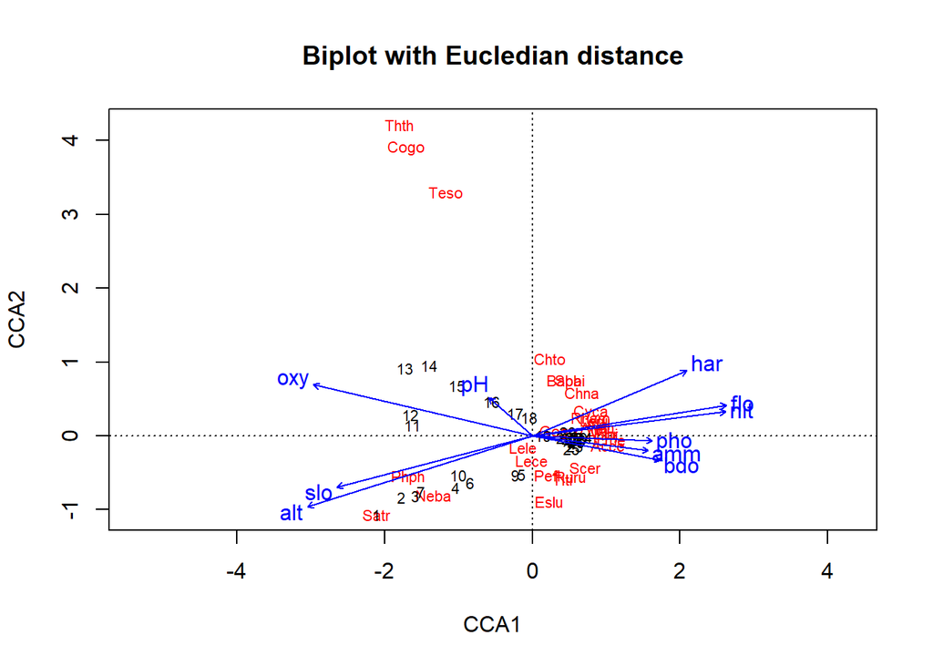

```r
plot(cca_env, scaling = 1,
     main = 'Biplot with Eucledian distance')
```

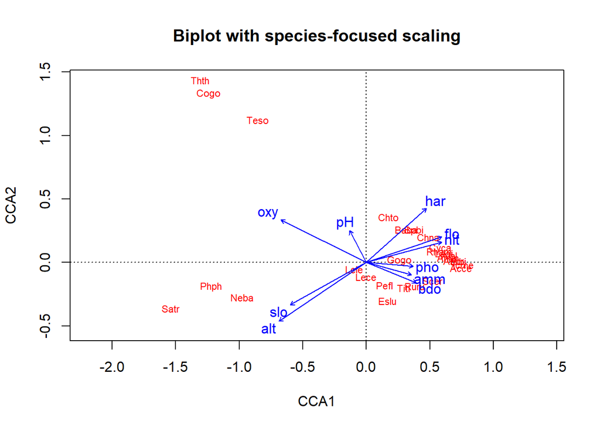

```r
plot(cca_env, scaling = 2,
     display = c("species", "cn"),
     main = "Biplot with species-focused scaling")
```

On biplots I see that the most species are influenced by stream flow, hardness of water and nitrogen levels. Also there are two separate groups: Thymallus thymallus (Thth), Cottus gobio (Cogo) and Telestes soufia agassizi (Teso) are more present in high oxygen environment; Phoxinus phoxinus (Phph), Nemacheilus barbatulus (Nebo) and Salmo trutta fario (Satr) prefer the high slope and altitude places.

```r
anova(cca_env)
```

```
## Permutation test for cca under reduced model
## Permutation: free
## Number of permutations: 999
##
## Model: cca(formula = fish ~ alt + slo + flo + pH + har + pho + nit + amm + oxy + bdo, data = no_dfs)
##          Df ChiSquare      F Pr(>F)
## Model    10   0.81402 4.1521  0.001 ***
## Residual 18   0.35289
## ---
## Signif. codes:  0 '***' 0.001 '**' 0.01 '*' 0.05 '.' 0.1 ' ' 1
```

Now let’s find out which of the factors is the most influential

```r
anova(cca_env, by="term")
```

```
## Permutation test for cca under reduced model
## Terms added sequentially (first to last)
## Permutation: free
## Number of permutations: 999
##
## Model: cca(formula = fish ~ alt + slo + flo + pH + har + pho + nit + amm + oxy + bdo, data = no_dfs)
##          Df ChiSquare       F Pr(>F)
## alt       1   0.37565 19.1611  0.001 ***
## slo       1   0.02054  1.0477  0.303
## flo       1   0.04832  2.4647  0.044 *
## pH        1   0.05461  2.7853  0.025 *
## har       1   0.04901  2.4997  0.052 .
## pho       1   0.04924  2.5117  0.031 *
## nit       1   0.03395  1.7318  0.097 .
## amm       1   0.01398  0.7132  0.570
## oxy       1   0.14630  7.4622  0.001 ***
## bdo       1   0.02242  1.1438  0.265
## Residual 18   0.35289
## ---
## Signif. codes:  0 '***' 0.001 '**' 0.01 '*' 0.05 '.' 0.1 ' ' 1
```